# [주간] 기업의 종가와 확진자 수 상관관계

## 0. Settings

```python
import pandas as pd
import numpy as np
import pandas_datareader as pdr
import requests
from bs4 import BeautifulSoup

import matplotlib.pyplot as plt
plt.rc("font", family="Malgun Gothic")
plt.rc("axes", unicode_minus=False)
plt.style.use("fivethirtyeight")
from IPython.display import set_matplotlib_formats
set_matplotlib_formats("retina")
%matplotlib inline
```

## 1. COVID19 데이터

**['Date', 'Daily_cases', 'Week', 'Day', 'Weekly_cases']**  
**날짜 / 일일 확진자 수 / 주차 / 요일 / 주차 확진자수 합계**

```python
covid = pd.read_excel('practice_covid.xlsx')
covid.head()
```

|  | Date | New_cases |
| --- | --- | --- |
| 0 | 2020-01-03 | 0 |
| 1 | 2020-01-04 | 0 |
| 2 | 2020-01-05 | 0 |
| 3 | 2020-01-06 | 0 |
| 4 | 2020-01-07 | 0 |

### 1.1 Date + 'Week', 'Day' 컬럼 추가

- 이때, Week 은 해당 연도의 몇 번째 주차인지 알려주는 컬럼입니다.
- 요일은 0=월요일, 4=금요일, 6=일요일 입니다. 즉, 한 주차는 월요일~일요일 입니다.
- covid 데이터는 주차(0~6) 별 New_cases의 합계 | stock 데이터는 금요일(4) 종가  
  이렇게 하기로 했는데, 그렇게 해도 문제 없습니다.  
  다만, merge 할 때는 주차로 merge 해야하므로, stock 데이터에도 'Week' 컬럼을 추가 합니다.  
  또한, 헷갈리지 않도록 여기에도 'Day' 컬럼을 추가해두겠습니다.

```python
# Date가 해당 연도의 몇 번째 주차인지 알려주는 컬럼을 추가 합니다.
# 월~일 = 하나의 week
covid["Week"] = covid["Date"].dt.week
covid[["Date", "Week", " New_cases"]].head()
```

|  | Date | Week | New_cases |
| --- | --- | --- | --- |
| 0 | 2020-01-03 | 1 | 0 |
| 1 | 2020-01-04 | 1 | 0 |
| 2 | 2020-01-05 | 1 | 0 |
| 3 | 2020-01-06 | 2 | 0 |
| 4 | 2020-01-07 | 2 | 0 |

```python
# 무슨 요일인지 추출합니다.
# 0=월요일 , 4=금요일
# covid["새컬럼명"] = covid["빼오려는 날짜 컬럼"].dt.dayofweek
covid["Day"] = covid["Date"].dt.dayofweek
covid[["Date", "Week", "Day", " New_cases"]].head()
```

|  | Date | Week | Day | New_cases |
| --- | --- | --- | --- | --- |
| 0 | 2020-01-03 | 1 | 4 | 0 |
| 1 | 2020-01-04 | 1 | 5 | 0 |
| 2 | 2020-01-05 | 1 | 6 | 0 |
| 3 | 2020-01-06 | 2 | 0 | 0 |
| 4 | 2020-01-07 | 2 | 1 | 0 |

### 1.2 주차 별 확진자수 'Weekly_cases' 추가

```python
# 주차 별 확진자 수를 구합니다.
covid_w= covid.groupby(["Week"])[" New_cases"].sum()
covid_w = pd.DataFrame(covid_w)
covid_w.columns = ['Weekly_cases']
covid_w.reset_index()
covid_w.head()
```

| Week | Weekly_cases |
| --- | --- |
| 1 | 0 |
| 2 | 0 |
| 3 | 5 |
| 4 | 2 |
| 5 | 12 |

```python
# 기존 데이터에 주차 별 확진자수 컬럼을 groupby를 통해 추가합니다.
# 주의: 돌릴 때마다 새 컬럼 추가되므로 여기 손대면 처음부터 다시 돌릴 것
covid = covid.merge(covid_w, left_on="Week", right_on=covid_w.index, how="left")
covid.head()
```

|  | Date | New_cases | Week | Day | Weekly_cases |
| --- | --- | --- | --- | --- | --- |
| 0 | 2020-01-03 | 0 | 1 | 4 | 0 |
| 1 | 2020-01-04 | 0 | 1 | 5 | 0 |
| 2 | 2020-01-05 | 0 | 1 | 6 | 0 |
| 3 | 2020-01-06 | 0 | 2 | 0 | 0 |
| 4 | 2020-01-07 | 0 | 2 | 1 | 0 |

```python
# 컬럼 명을 변경합니다.
covid.columns = ["Date", "Daily_cases", "Week", "Day", "Weekly_cases"]
covid.head()
```

|  | Date | Daily_cases | Week | Day | Weekly_cases |
| --- | --- | --- | --- | --- | --- |
| 0 | 2020-01-03 | 0 | 1 | 4 | 0 |
| 1 | 2020-01-04 | 0 | 1 | 5 | 0 |
| 2 | 2020-01-05 | 0 | 1 | 6 | 0 |
| 3 | 2020-01-06 | 0 | 2 | 0 | 0 |
| 4 | 2020-01-07 | 0 | 2 | 1 | 0 |

### 1.3 그래프

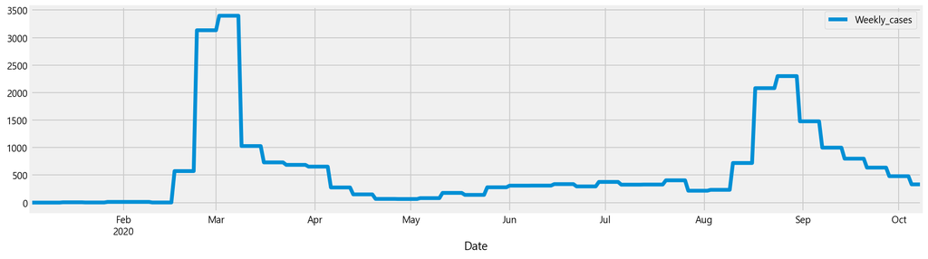

```python
covid.plot(x='Date', y='Weekly_cases', figsize=(15,4))
```

### 1.4 저장하기

```python
# 필요할지도 모르니 다 저장
covid.to_excel("1013_covid_daily_weekly.xlsx", index=False, encoding="utf8")
covid.to_pickle("1013_covid_daily_weekly.pkl")
covid.to_html()
covid.to_html("1013_covid_daily_weekly.html", index=False)
```

```python
# 잘 저장되었나 확인
covid = pd.read_excel('1013_covid_daily_weekly.xlsx')
covid.tail()
```

|  | Date | Daily_cases | Week | Day | Weekly_cases |
| --- | --- | --- | --- | --- | --- |
| 275 | 2020-10-04 | 64 | 40 | 6 | 480 |
| 276 | 2020-10-05 | 73 | 41 | 0 | 331 |
| 277 | 2020-10-06 | 75 | 41 | 1 | 331 |
| 278 | 2020-10-07 | 114 | 41 | 2 | 331 |
| 279 | 2020-10-08 | 69 | 41 | 3 | 331 |

============================현재(20.10.13 21:00) 여기까지 완료 (해인)==============================

## 2. 기업 주가 정보

**['Date', 'Company', 'Close', 'Week', 'Day' 'Weekly_close']**  
**날짜 / 기업명 / 일일 종가 / 주차 / 요일 / 금요일 종가**

### 2.1 특정 기업 정보 크롤링 ['날짜', '종가']

#### 2.1.1 상장법인 목록 불러오기 ['회사명', '종목코드']

```python
# 회사명으로 주식 종목 코드를 획득할 수 있도록 하는 함수
def get_code(df, name):
    code = df.query("name=='{}'".format(name))['code'].to_string(index=False)
    # 위와같이 code명을 가져오면 앞에 공백이 붙어있는 상황이 발생하여 앞뒤로 sript() 하여 공백 제거
    code = code.strip()
    return code

# excel 파일을 다운로드하는거와 동시에 pandas에 load하기
# 흔히 사용하는 df라는 변수는 data frame을 의미합니다.
company_code_df = pd.read_html('http://kind.krx.co.kr/corpgeneral/corpList.do?method=download', header=0)[0]

# data frame정리
company_code_df = company_code_df[['회사명', '종목코드']]

# data frame title 변경 '회사명' = name, 종목코드 = 'code'
company_code_df = company_code_df.rename(columns={'회사명': 'name', '종목코드': 'code'})

# 종목코드는 6자리로 구분되기때문에 0을 채워 6자리로 변경
company_code_df.code = company_code_df.code.map('{:06d}'.format)
company_code_df.head()
```

|  | name | code |
| --- | --- | --- |
| 0 | JS전선 | 005560 |
| 1 | 거북선2호 | 101380 |
| 2 | 거북선6호 | 114140 |
| 3 | 교보메리츠 | 064900 |
| 4 | 국제관광공사 | 028780 |

#### 2.1.2 기업의 주가 정보 크롤링

```python
def get_price(company_code):
    # count=439에서 3000은 과거 439 영업일간의 데이터를 의미. 사용자가 조절 가능 - 2019.01.02 ~ 2020.10.13
    url = "https://fchart.stock.naver.com/sise.nhn?symbol={}&timeframe=day&count=439&requestType=0".format(company_code)
    get_result = requests.get(url)
    bs_obj = BeautifulSoup(get_result.content, "html.parser")

    # information
    inf = bs_obj.select('item')
    columns = ['Date', 'Open' ,'High', 'Low', 'Close', 'Volume']
    df1_inf = pd.DataFrame([], columns = columns, index = range(len(inf)))

    for i in range(len(inf)):
        df1_inf.iloc[i] = str(inf[i]['data']).split('|')

    df1_inf.index = pd.to_datetime(df1_inf['Date'])

    return df1_inf.drop('Date', axis=1).astype(float)
```

```python
samsung_price = get_price('025980') #추후에 여기 종목 코드 - 1.1.1 을 넣어서 반복 될 수 있도록 만들기
samsung_price.head()
```

| Date | Open | High | Low | Close | Volume |
| --- | --- | --- | --- | --- | --- |
| 2019-01-02 | 19450.0 | 19900.0 | 18550.0 | 19800.0 | 5371377.0 |
| 2019-01-03 | 19700.0 | 21200.0 | 19300.0 | 20400.0 | 6705977.0 |
| 2019-01-04 | 19950.0 | 21650.0 | 19500.0 | 21650.0 | 3791053.0 |
| 2019-01-07 | 21500.0 | 22100.0 | 21100.0 | 21900.0 | 3955680.0 |
| 2019-01-08 | 21800.0 | 27700.0 | 21750.0 | 26100.0 | 25567152.0 |

```python
# 코딩하기 힘드니까 Date를 인덱스에서 빼줍니다.
samsung = samsung_price[["Close"]]
samsung = samsung.reset_index()
samsung.tail()
```

|  | Date | Close |
| --- | --- | --- |
| 434 | 2020-10-06 | 8910.0 |
| 435 | 2020-10-07 | 8910.0 |
| 436 | 2020-10-08 | 8960.0 |
| 437 | 2020-10-12 | 9150.0 |
| 438 | 2020-10-13 | 9030.0 |

1.1.1 과 1.1.2 를 잘 섞어서 for 문으로 만들면 모든 상장 기업(3875)의 주가 정보를 얻을 수 있다.  
Date가 인덱스에 있어서 건들지 못하는 게 있는데, 최종으로는 넣더라도 지금은 컬럼으로 어떻게 빼야할듯.. (지금 상태에서 for문 만들면 복잡해져서 일단 보류)

#### for문으로 만들면 최종으로 기대하는 모양 ['Date', 'Company', 'Close', 'Week', 'Day', 'Weekly_close']

- 현재는 company 이름 혹은 코드가 안나오는데, 어떻게 만들면 나오게 할 수 있을듯!
- 이때, weekly_close = friday_close
- 이때, 'Week'은 코로나 데이터의 'Week'과 일치 (아마 따로 조치 안해도 자동으로 같을 것, 다만! 2019, 2020 연도가 두 개라 어찌 나올지..?)

### 2.2 Date + 'Week', 'Day' 컬럼 추가

여기에서 기대하는 모양의 컬럼 ['Date', 'Week', 'Day' 'Weekly_Close']

- 이때, 나중에 코로나 데이터 merge를 위해서 'Week'은 금요일로 하지 않고 주차로 해야할듯
- 그러면서 Weekly Close는 금요일 종가를 써야하므로, Week 외에 별도로 Day(요일) 컬럼도 추가

```python
# 주의: 왜인지 모르겠는데 39주차 (9월25일)까지만 나옴
# 해당 연도의 몇 번째 "주차"인지 추출합니다.
samsung["Week"] = samsung["Date"].dt.week
samsung[["Date", "Week", "Close"]].tail()
```

|  | Date | Week | Close |
| --- | --- | --- | --- |
| 434 | 2020-10-06 | 41 | 8910.0 |
| 435 | 2020-10-07 | 41 | 8910.0 |
| 436 | 2020-10-08 | 41 | 8960.0 |
| 437 | 2020-10-12 | 42 | 9150.0 |
| 438 | 2020-10-13 | 42 | 9030.0 |

```python
# 요일을 추출합니다.
samsung["Day"] = samsung["Date"].dt.dayofweek
samsung.tail()
```

|  | Date | Close | Week | Day |
| --- | --- | --- | --- | --- |
| 434 | 2020-10-06 | 8910.0 | 41 | 1 |
| 435 | 2020-10-07 | 8910.0 | 41 | 2 |
| 436 | 2020-10-08 | 8960.0 | 41 | 3 |
| 437 | 2020-10-12 | 9150.0 | 42 | 0 |
| 438 | 2020-10-13 | 9030.0 | 42 | 1 |

### 2.3 금요일 종가만 남기기

- 'Weekly_close' 라고 쓰고 'Friday_close'라고 읽는다.

```python
samsung = samsung[samsung['Day'].isin([4])]
samsung.tail()
```

|  | Date | Close | Week | Day |
| --- | --- | --- | --- | --- |
| 410 | 2020-08-28 | 9040.0 | 35 | 4 |
| 415 | 2020-09-04 | 8930.0 | 36 | 4 |
| 420 | 2020-09-11 | 9100.0 | 37 | 4 |
| 425 | 2020-09-18 | 9290.0 | 38 | 4 |
| 430 | 2020-09-25 | 9330.0 | 39 | 4 |

### 2.3 그래프

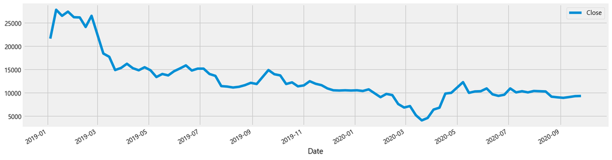

```python
samsung.plot(x='Date', y='Close', figsize=(15,4))
```

### 2.4 저장하기

```python
samsung.to_excel("weekly_samsung.xlsx", index=False, encoding="utf8")
samsung.to_pickle("weekly_samsung.pkl")
samsung.to_html()
samsung.to_html("weekly_samsung", index=False)
```

## 3.covid + samsung Merge

- covid 데이터 가공

```python
# covid 금요일만 남기기
# 이때 weekly_cases 있으니까 걱정 ㄴㄴ
covid = covid[covid['Day'].isin([4])]
covid = covid.drop([0,7], 0)
covid.head()
```

|  | Date | Daily_cases | Week | Day | Weekly_cases |
| --- | --- | --- | --- | --- | --- |
| 14 | 2020-01-17 | 0 | 3 | 4 | 5 |
| 21 | 2020-01-24 | 1 | 4 | 4 | 2 |
| 28 | 2020-01-31 | 5 | 5 | 4 | 12 |
| 35 | 2020-02-07 | 1 | 6 | 4 | 12 |
| 42 | 2020-02-14 | 0 | 7 | 4 | 2 |

### 3.1 Samsung + covid

```python
# merge
samsung_covid = samsung.merge(covid, left_on="Date", right_on=covid["Date"], how="right")
samsung_covid
```

|  | Date | Date_x | Close | Week_x | Day_x | Date_y | Daily_cases | Week_y | Day_y | Weekly_cases |
| --- | --- | --- | --- | --- | --- | --- | --- | --- | --- | --- |
| 0 | 2020-01-17 | 2020-01-17 | 10750.0 | 3.0 | 4.0 | 2020-01-17 | 0 | 3 | 4 | 5 |
| 1 | 2020-01-31 | 2020-01-31 | 9070.0 | 5.0 | 4.0 | 2020-01-31 | 5 | 5 | 4 | 12 |
| 2 | 2020-02-07 | 2020-02-07 | 9770.0 | 6.0 | 4.0 | 2020-02-07 | 1 | 6 | 4 | 12 |
| 3 | 2020-02-14 | 2020-02-14 | 9520.0 | 7.0 | 4.0 | 2020-02-14 | 0 | 7 | 4 | 2 |
| 4 | 2020-02-21 | 2020-02-21 | 7600.0 | 8.0 | 4.0 | 2020-02-21 | 100 | 8 | 4 | 573 |
| 5 | 2020-02-28 | 2020-02-28 | 6850.0 | 9.0 | 4.0 | 2020-02-28 | 571 | 9 | 4 | 3134 |
| 6 | 2020-03-06 | 2020-03-06 | 7160.0 | 10.0 | 4.0 | 2020-03-06 | 518 | 10 | 4 | 3398 |
| 7 | 2020-03-13 | 2020-03-13 | 5200.0 | 11.0 | 4.0 | 2020-03-13 | 0 | 11 | 4 | 1028 |
| 8 | 2020-03-20 | 2020-03-20 | 4085.0 | 12.0 | 4.0 | 2020-03-20 | 147 | 12 | 4 | 731 |
| 9 | 2020-03-27 | 2020-03-27 | 4610.0 | 13.0 | 4.0 | 2020-03-27 | 91 | 13 | 4 | 686 |
| 10 | 2020-04-03 | 2020-04-03 | 6410.0 | 14.0 | 4.0 | 2020-04-03 | 86 | 14 | 4 | 654 |
| 11 | 2020-04-10 | 2020-04-10 | 6810.0 | 15.0 | 4.0 | 2020-04-10 | 27 | 15 | 4 | 275 |
| 12 | 2020-04-17 | 2020-04-17 | 9850.0 | 16.0 | 4.0 | 2020-04-17 | 22 | 16 | 4 | 149 |
| 13 | 2020-04-24 | 2020-04-24 | 10000.0 | 17.0 | 4.0 | 2020-04-24 | 6 | 17 | 4 | 67 |
| 14 | 2020-05-08 | 2020-05-08 | 12300.0 | 19.0 | 4.0 | 2020-05-08 | 12 | 19 | 4 | 81 |
| 15 | 2020-05-15 | 2020-05-15 | 10000.0 | 20.0 | 4.0 | 2020-05-15 | 27 | 20 | 4 | 176 |
| 16 | 2020-05-22 | 2020-05-22 | 10300.0 | 21.0 | 4.0 | 2020-05-22 | 20 | 21 | 4 | 140 |
| 17 | 2020-05-29 | 2020-05-29 | 10350.0 | 22.0 | 4.0 | 2020-05-29 | 58 | 22 | 4 | 278 |
| 18 | 2020-06-05 | 2020-06-05 | 10950.0 | 23.0 | 4.0 | 2020-06-05 | 39 | 23 | 4 | 308 |
| 19 | 2020-06-12 | 2020-06-12 | 9680.0 | 24.0 | 4.0 | 2020-06-12 | 56 | 24 | 4 | 309 |
| 20 | 2020-06-19 | 2020-06-19 | 9350.0 | 25.0 | 4.0 | 2020-06-19 | 49 | 25 | 4 | 336 |
| 21 | 2020-06-26 | 2020-06-26 | 9600.0 | 26.0 | 4.0 | 2020-06-26 | 39 | 26 | 4 | 294 |
| 22 | 2020-07-03 | 2020-07-03 | 10950.0 | 27.0 | 4.0 | 2020-07-03 | 63 | 27 | 4 | 376 |
| 23 | 2020-07-10 | 2020-07-10 | 10100.0 | 28.0 | 4.0 | 2020-07-10 | 45 | 28 | 4 | 326 |
| 24 | 2020-07-17 | 2020-07-17 | 10350.0 | 29.0 | 4.0 | 2020-07-17 | 60 | 29 | 4 | 328 |
| 25 | 2020-07-24 | 2020-07-24 | 10100.0 | 30.0 | 4.0 | 2020-07-24 | 41 | 30 | 4 | 405 |
| 26 | 2020-07-31 | 2020-07-31 | 10400.0 | 31.0 | 4.0 | 2020-07-31 | 36 | 31 | 4 | 216 |
| 27 | 2020-08-07 | 2020-08-07 | 10350.0 | 32.0 | 4.0 | 2020-08-07 | 20 | 32 | 4 | 232 |
| 28 | 2020-08-14 | 2020-08-14 | 10300.0 | 33.0 | 4.0 | 2020-08-14 | 103 | 33 | 4 | 720 |
| 29 | 2020-08-21 | 2020-08-21 | 9180.0 | 34.0 | 4.0 | 2020-08-21 | 324 | 34 | 4 | 2081 |
| 30 | 2020-08-28 | 2020-08-28 | 9040.0 | 35.0 | 4.0 | 2020-08-28 | 371 | 35 | 4 | 2300 |
| 31 | 2020-09-04 | 2020-09-04 | 8930.0 | 36.0 | 4.0 | 2020-09-04 | 198 | 36 | 4 | 1478 |
| 32 | 2020-09-11 | 2020-09-11 | 9100.0 | 37.0 | 4.0 | 2020-09-11 | 176 | 37 | 4 | 999 |
| 33 | 2020-09-18 | 2020-09-18 | 9290.0 | 38.0 | 4.0 | 2020-09-18 | 126 | 38 | 4 | 799 |
| 34 | 2020-09-25 | 2020-09-25 | 9330.0 | 39.0 | 4.0 | 2020-09-25 | 114 | 39 | 4 | 636 |
| 35 | 2020-01-24 | NaT | NaN | NaN | NaN | 2020-01-24 | 1 | 4 | 4 | 2 |
| 36 | 2020-05-01 | NaT | NaN | NaN | NaN | 2020-05-01 | 9 | 18 | 4 | 65 |
| 37 | 2020-10-02 | NaT | NaN | NaN | NaN | 2020-10-02 | 63 | 40 | 4 | 480 |

```python
# 확인용 (위의 코드 여러 번 돌리면 컬럼 늘어나니까 여기서 확인하기)
samsung_covid[20:]
```

|  | Date | Date_x | Close | Week_x | Day_x | Date_y | Daily_cases | Week_y | Day_y | Weekly_cases |
| --- | --- | --- | --- | --- | --- | --- | --- | --- | --- | --- |
| 20 | 2020-06-19 | 2020-06-19 | 9350.0 | 25.0 | 4.0 | 2020-06-19 | 49 | 25 | 4 | 336 |
| 21 | 2020-06-26 | 2020-06-26 | 9600.0 | 26.0 | 4.0 | 2020-06-26 | 39 | 26 | 4 | 294 |
| 22 | 2020-07-03 | 2020-07-03 | 10950.0 | 27.0 | 4.0 | 2020-07-03 | 63 | 27 | 4 | 376 |
| 23 | 2020-07-10 | 2020-07-10 | 10100.0 | 28.0 | 4.0 | 2020-07-10 | 45 | 28 | 4 | 326 |
| 24 | 2020-07-17 | 2020-07-17 | 10350.0 | 29.0 | 4.0 | 2020-07-17 | 60 | 29 | 4 | 328 |
| 25 | 2020-07-24 | 2020-07-24 | 10100.0 | 30.0 | 4.0 | 2020-07-24 | 41 | 30 | 4 | 405 |
| 26 | 2020-07-31 | 2020-07-31 | 10400.0 | 31.0 | 4.0 | 2020-07-31 | 36 | 31 | 4 | 216 |
| 27 | 2020-08-07 | 2020-08-07 | 10350.0 | 32.0 | 4.0 | 2020-08-07 | 20 | 32 | 4 | 232 |
| 28 | 2020-08-14 | 2020-08-14 | 10300.0 | 33.0 | 4.0 | 2020-08-14 | 103 | 33 | 4 | 720 |
| 29 | 2020-08-21 | 2020-08-21 | 9180.0 | 34.0 | 4.0 | 2020-08-21 | 324 | 34 | 4 | 2081 |
| 30 | 2020-08-28 | 2020-08-28 | 9040.0 | 35.0 | 4.0 | 2020-08-28 | 371 | 35 | 4 | 2300 |
| 31 | 2020-09-04 | 2020-09-04 | 8930.0 | 36.0 | 4.0 | 2020-09-04 | 198 | 36 | 4 | 1478 |
| 32 | 2020-09-11 | 2020-09-11 | 9100.0 | 37.0 | 4.0 | 2020-09-11 | 176 | 37 | 4 | 999 |
| 33 | 2020-09-18 | 2020-09-18 | 9290.0 | 38.0 | 4.0 | 2020-09-18 | 126 | 38 | 4 | 799 |
| 34 | 2020-09-25 | 2020-09-25 | 9330.0 | 39.0 | 4.0 | 2020-09-25 | 114 | 39 | 4 | 636 |
| 35 | 2020-01-24 | NaT | NaN | NaN | NaN | 2020-01-24 | 1 | 4 | 4 | 2 |
| 36 | 2020-05-01 | NaT | NaN | NaN | NaN | 2020-05-01 | 9 | 18 | 4 | 65 |
| 37 | 2020-10-02 | NaT | NaN | NaN | NaN | 2020-10-02 | 63 | 40 | 4 | 480 |

### 3.2 날짜/금요종가/주간확진자

- 필요한 컬럼만 남기기

```python
samsung_covid = samsung_covid[["Date", "Close", "Weekly_cases"]]
samsung_covid
```

|  | Date | Close | Weekly_cases |
| --- | --- | --- | --- |
| 0 | 2020-01-17 | 10750.0 | 5 |
| 1 | 2020-01-31 | 9070.0 | 12 |
| 2 | 2020-02-07 | 9770.0 | 12 |
| 3 | 2020-02-14 | 9520.0 | 2 |
| 4 | 2020-02-21 | 7600.0 | 573 |
| 5 | 2020-02-28 | 6850.0 | 3134 |
| 6 | 2020-03-06 | 7160.0 | 3398 |
| 7 | 2020-03-13 | 5200.0 | 1028 |
| 8 | 2020-03-20 | 4085.0 | 731 |
| 9 | 2020-03-27 | 4610.0 | 686 |
| 10 | 2020-04-03 | 6410.0 | 654 |
| 11 | 2020-04-10 | 6810.0 | 275 |
| 12 | 2020-04-17 | 9850.0 | 149 |
| 13 | 2020-04-24 | 10000.0 | 67 |
| 14 | 2020-05-08 | 12300.0 | 81 |
| 15 | 2020-05-15 | 10000.0 | 176 |
| 16 | 2020-05-22 | 10300.0 | 140 |
| 17 | 2020-05-29 | 10350.0 | 278 |
| 18 | 2020-06-05 | 10950.0 | 308 |
| 19 | 2020-06-12 | 9680.0 | 309 |
| 20 | 2020-06-19 | 9350.0 | 336 |
| 21 | 2020-06-26 | 9600.0 | 294 |
| 22 | 2020-07-03 | 10950.0 | 376 |
| 23 | 2020-07-10 | 10100.0 | 326 |
| 24 | 2020-07-17 | 10350.0 | 328 |
| 25 | 2020-07-24 | 10100.0 | 405 |
| 26 | 2020-07-31 | 10400.0 | 216 |
| 27 | 2020-08-07 | 10350.0 | 232 |
| 28 | 2020-08-14 | 10300.0 | 720 |
| 29 | 2020-08-21 | 9180.0 | 2081 |
| 30 | 2020-08-28 | 9040.0 | 2300 |
| 31 | 2020-09-04 | 8930.0 | 1478 |
| 32 | 2020-09-11 | 9100.0 | 999 |
| 33 | 2020-09-18 | 9290.0 | 799 |
| 34 | 2020-09-25 | 9330.0 | 636 |
| 35 | 2020-01-24 | NaN | 2 |
| 36 | 2020-05-01 | NaN | 65 |
| 37 | 2020-10-02 | NaN | 480 |

### 3.3 주간 확진자수 fillna

```python
samsung_covid["Weekly_cases"] = samsung_covid["Weekly_cases"].fillna(0)
samsung_covid
```

|  | Date | Close | Weekly_cases |
| --- | --- | --- | --- |
| 0 | 2020-01-17 | 10750.0 | 5 |
| 1 | 2020-01-31 | 9070.0 | 12 |
| 2 | 2020-02-07 | 9770.0 | 12 |
| 3 | 2020-02-14 | 9520.0 | 2 |
| 4 | 2020-02-21 | 7600.0 | 573 |
| 5 | 2020-02-28 | 6850.0 | 3134 |
| 6 | 2020-03-06 | 7160.0 | 3398 |
| 7 | 2020-03-13 | 5200.0 | 1028 |
| 8 | 2020-03-20 | 4085.0 | 731 |
| 9 | 2020-03-27 | 4610.0 | 686 |
| 10 | 2020-04-03 | 6410.0 | 654 |
| 11 | 2020-04-10 | 6810.0 | 275 |
| 12 | 2020-04-17 | 9850.0 | 149 |
| 13 | 2020-04-24 | 10000.0 | 67 |
| 14 | 2020-05-08 | 12300.0 | 81 |
| 15 | 2020-05-15 | 10000.0 | 176 |
| 16 | 2020-05-22 | 10300.0 | 140 |
| 17 | 2020-05-29 | 10350.0 | 278 |
| 18 | 2020-06-05 | 10950.0 | 308 |
| 19 | 2020-06-12 | 9680.0 | 309 |
| 20 | 2020-06-19 | 9350.0 | 336 |
| 21 | 2020-06-26 | 9600.0 | 294 |
| 22 | 2020-07-03 | 10950.0 | 376 |
| 23 | 2020-07-10 | 10100.0 | 326 |
| 24 | 2020-07-17 | 10350.0 | 328 |
| 25 | 2020-07-24 | 10100.0 | 405 |
| 26 | 2020-07-31 | 10400.0 | 216 |
| 27 | 2020-08-07 | 10350.0 | 232 |
| 28 | 2020-08-14 | 10300.0 | 720 |
| 29 | 2020-08-21 | 9180.0 | 2081 |
| 30 | 2020-08-28 | 9040.0 | 2300 |
| 31 | 2020-09-04 | 8930.0 | 1478 |
| 32 | 2020-09-11 | 9100.0 | 999 |
| 33 | 2020-09-18 | 9290.0 | 799 |
| 34 | 2020-09-25 | 9330.0 | 636 |
| 35 | 2020-01-24 | NaN | 2 |
| 36 | 2020-05-01 | NaN | 65 |
| 37 | 2020-10-02 | NaN | 480 |

### 3.4 그래프

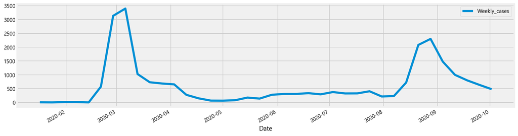

```python
samsung_covid.plot(x='Date', y='Weekly_cases', figsize=(15,4))
```

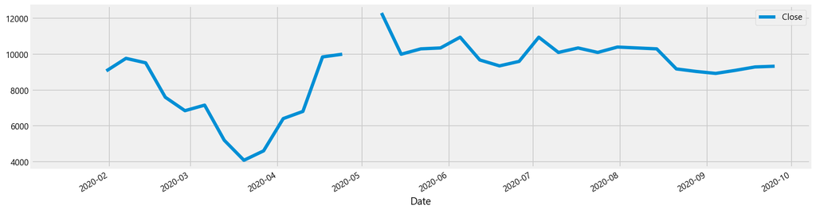

```python
samsung_covid.plot(x='Date', y='Close', figsize=(15,4))
```

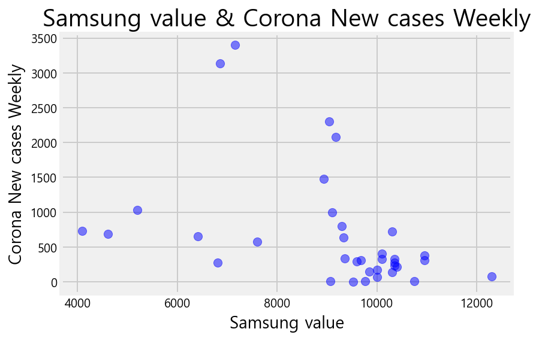

```python
samsung_covid.plot.scatter(x='Close',
                  y='Weekly_cases',
                  s=50, # marker size
                  c='blue',
                  alpha=0.5)
plt.title('Samsung value & Corona New cases Weekly', fontsize=20)
plt.xlabel('Samsung value', fontsize=14)
plt.ylabel('Corona New cases Weekly', fontsize=14)
plt.show()
```

### 3.5 저장하기

```python
samsung_covid.to_excel("samsung_covid.xlsx", index=False, encoding="utf8")
samsung_covid.to_pickle("samsung_covid.pkl")
samsung_covid.to_html()
samsung_covid.to_html("samsung_covid.html", index=False)
```

```python
# 확인하기
check = pd.read_excel("samsung_covid.xlsx")
check.head()
```

|  | Date | Close | Weekly_cases |
| --- | --- | --- | --- |
| 0 | 2020-01-17 | 10750.0 | 5 |
| 1 | 2020-01-31 | 9070.0 | 12 |
| 2 | 2020-02-07 | 9770.0 | 12 |
| 3 | 2020-02-14 | 9520.0 | 2 |
| 4 | 2020-02-21 | 7600.0 | 573 |

## 4. 회귀분석

```python
from statsmodels.formula.api import ols
```

```python
res = ols('Close ~ Weekly_cases', data=samsung_covid).fit()
res.summary()
```

OLS Regression Results

| Dep. Variable: | Close | R-squared: | 0.164 |
| --- | --- | --- | --- |
| Model: | OLS | Adj. R-squared: | 0.139 |
| Method: | Least Squares | F-statistic: | 6.488 |
| Date: | Wed, 14 Oct 2020 | Prob (F-statistic): | 0.0157 |
| Time: | 00:31:36 | Log-Likelihood: | -309.67 |
| No. Observations: | 35 | AIC: | 623.3 |
| Df Residuals: | 33 | BIC: | 626.4 |
| Df Model: | 1 |  |  |
| Covariance Type: | nonrobust |  |  |

|  | coef | std err | t | P>\|t\| | [0.025 | 0.975] |
| --- | --- | --- | --- | --- | --- | --- |
| Intercept | 9682.2074 | 377.710 | 25.634 | 0.000 | 8913.752 | 1.05e+04 |
| Weekly_cases | -0.9022 | 0.354 | -2.547 | 0.016 | -1.623 | -0.182 |

| Omnibus: | 16.204 | Durbin-Watson: | 0.556 |
| --- | --- | --- | --- |
| Prob(Omnibus): | 0.000 | Jarque-Bera (JB): | 17.905 |
| Skew: | -1.520 | Prob(JB): | 0.000129 |
| Kurtosis: | 4.742 | Cond. No. | 1.37e+03 |

Warnings:  
[1] Standard Errors assume that the covariance matrix of the errors is correctly specified.  
[2] The condition number is large, 1.37e+03. This might indicate that there are  
strong multicollinearity or other numerical problems.